# ✍ Student: Mohammad Osmanpoor

# 🏢 University: Macquarie University

# 📅 Assignment: Week 11 and 12 -- Task1 MALICIOUS WEB DETECTION WITH 1D CNN (Convolution Neural Network)

### 📄 **Debugging Report: Fixing Model Training Issues**

During the implementation of the "Malicious Website Detection using CNN" project, I encountered several errors in the original notebook that required careful debugging and analysis. One major issue was the improper import of `plot_model` from a deprecated path (`keras.utils.vis_utils`), which I resolved by updating the import to `from tensorflow.keras.utils import plot_model` and installing necessary dependencies like `pydot` and `graphviz`.

Later, I faced an `AttributeError` due to using the outdated function `tf.set_random_seed()`, which is not valid in TensorFlow 2.x. I corrected this by replacing it with the appropriate `tf.random.set_seed()` function.

Another critical error was a `TypeError` caused by trying to iterate over a `tldextract.ExtractResult` object. I rewrote the URL parsing logic to explicitly access the `.subdomain`, `.domain`, and `.suffix` attributes rather than unpacking them directly.

The most complex issue arose during `model.fit()` where I encountered a `ValueError: Invalid dtype: object`. After reviewing the model structure, I discovered that the input data (especially categorical features like subdomain, domain, and suffix) was still in `object` or pandas Series format. I resolved this by explicitly converting each input feature to a NumPy array with the correct numeric dtype (`float32` or `int32`) before passing them to the model.

Through this debugging process, I improved the code's robustness, compatibility with modern TensorFlow, and ensured successful training of the model. This experience enhanced my problem-solving skills and deepened my understanding of how data preprocessing impacts model performance.

# Questions

1. What is the precision of this mode?
2. What is the recall of this mode?
3. What is the relationship between high precision value and the classified malicious websites?
4. What is the relationship between low precision value and the classified malicious websites?

# ✍ `Question 1: What is the precision of this mode?`

The precision of the model is provided in the classification report, which evaluates the model's performance on the validation set after training. Precision for a class is the ratio of true positives (TP) to the total number of instances predicted as that class (TP + false positives, FP). Since the task is about detecting malicious URLs, I focus on the precision for the "malicious" class (label 1, "bad").

From the classification report:

Precision for label 1 (malicious): 0.99. This value indicates that 99% of the websites classified as malicious by the model are actually malicious. The confusion matrix supports this:

True Positives (TP) for label 1: 10975 (malicious websites correctly classified as malicious). False Positives (FP) for label 1: 56 (safe websites incorrectly classified as malicious). Precision = TP / (TP + FP) = 10975 / (10975 + 56) = 10975 / 11031 ≈ 0.9949, which rounds to 0.99, matching the classification report. Answer: The precision of this model for detecting malicious websites is 0.99, or 99%, meaning 99% of the websites classified as malicious are actually malicious.

# ✍ `Question 2: What is the recall of this mode?`

Recall (also known as sensitivity) measures the proportion of actual malicious websites that are correctly identified by the model. It is the ratio of true positives (TP) to the total number of actual instances of that class (TP + false negatives, FN). I focus on the recall for the "malicious" class (label 1).

From the classification report:

Recall for label 1 (malicious): 0.73. This value indicates that 73% of the actual malicious websites in the validation set are correctly identified by the model. The confusion matrix supports this:

True Positives (TP) for label 1: 10975. False Negatives (FN) for label 1: 4154 (malicious websites incorrectly classified as safe). Recall = TP / (TP + FN) = 10975 / (10975 + 4154) = 10975 / 15129 ≈ 0.7255, which rounds to 0.73, matching the classification report. Answer: The recall of this model for detecting malicious websites is 0.73, or 73%, meaning 73% of the actual malicious websites are correctly identified.

# ✍ `Question 3: What is the relationship between high precision value and the classified malicious websites?`

# ✍ `Question 4: What is the relationship between low precision value and the classified malicious websites?`

A low precision value, in contrast to the high precision of 0.99 observed in this model, would indicate a weaker relationship between the model's predictions and the actual malicious websites. A low precision value means a higher rate of false positives, where many websites classified as malicious are actually safe. For example, if the false positives (FP) were significantly higher than the 56 observed (e.g., if FP were 5000), the precision would drop to 10975 / (10975 + 5000) ≈ 0.687, meaning only 68.7% of the websites classified as malicious are actually malicious.

# also 2 below questions has mentioned in pdf file of assignment

# ✍ `Question 5 (Assignment Question 3): What does a lower precision value indicate?`

A lower precision value in the context of detecting malicious URLs indicates that the model has a higher rate of false positives. Precision is the proportion of websites classified as malicious that are actually malicious (true positives / (true positives + false positives)). A lower precision means that a significant number of websites flagged as malicious (label 1) are actually safe (label 0). Using the confusion matrix:

False Positives (FP): 56 (safe websites incorrectly classified as malicious). If FP were much higher (e.g., 5000), precision would drop, as shown in the previous question. A lower precision value suggests that the model is less reliable in its positive predictions, leading to a higher likelihood of misclassifying safe websites as malicious. In cybersecurity, this can result in unnecessary blocking or flagging of legitimate websites, which disrupts user access, erodes trust in the system, and increases the need for manual verification. The "precision vs val_precision" plot shows that the model's precision improves over epochs, avoiding this issue with a final precision of 0.99, but a lower precision would indicate a significant problem in the model's ability to accurately identify true threats.

`Answer:` A lower precision value indicates a higher rate of false positives, meaning many websites classified as malicious are actually safe. This leads to frequent misclassification of safe websites, causing unnecessary flagging, disrupted access to legitimate websites, reduced trust in the system, and increased manual verification efforts in cybersecurity.

# ✍ `Question 6 (Assignment Question 4): In contrast, what does a higher value of precision indicate?`

```python
from google.colab import drive
drive.mount('/content/drive')
```

```python
cd drive/MyDrive/week11_12
```

```
/content/drive/MyDrive/week11_12
```

```python
!pip install tldextract
```

```
Downloading tldextract-5.3.0-py3-none-any.whl (107 kB)
   ━━━━━━━━━━━━━━━━━━━━━━━━━━━━━━━━━━━━━━━━ 107.4/107.4 kB 5.8 MB/s eta 0:00:00
Downloading requests_file-2.1.0-py2.py3-none-any.whl (4.2 kB)
```

```python
import numpy as np
import pandas as pd
import re
import matplotlib.pyplot as plt
import matplotlib.image as mpimg
import seaborn as sns
import gc
import random
import os
import pickle
import tensorflow as tf
from tensorflow.python.util import deprecation
from urllib.parse import urlparse
import tldextract
```

```python
# i added this code
!pip install pydot graphviz
```

```python
from sklearn.model_selection import train_test_split
from tensorflow.keras.preprocessing.text import Tokenizer
from tensorflow.keras.preprocessing.sequence import pad_sequences
from tensorflow.keras import models, layers, backend, metrics
from tensorflow.keras.callbacks import EarlyStopping
# from keras.utils.vis_utils import plot_model # i changed this module to below module
from tensorflow.keras.utils import plot_model

from PIL import Image
from sklearn.metrics import confusion_matrix, classification_report
```

```python
# set random seed
os.environ['PYTHONHASHSEED'] = '0'
os.environ['TF_CPP_MIN_LOG_LEVEL'] = '2'
np.random.seed(0)
random.seed(0)
# tf.set_random_seed(0) # module 'tensorflow' has no attribute 'set_random_seed'
tf.random.set_seed(0)
```

```python
# other setup
%config InlineBackend.figure_format = 'retina'
pd.set_option('max_colwidth', 500)
deprecation._PRINT_DEPRECATION_WARNINGS = False
```

# Loading Data

```python
# load data
data = pd.read_csv('./malicious_url_dataset.csv')
# shuffle data
data = data.sample(frac=1, random_state=0)
print(f'Data size: {data.shape}')
data.head()
```

```
Data size: (420464, 2)
```

|  | url | label |
| --- | --- | --- |
| 36210 | a.kafunews.com/wp-includes/certificates/webmail.ccri.edu.html | bad |
| 77403 | en.wikipedia.org/wiki/Claude_Lemieux | good |
| 390133 | www.jklgdf789dh43.com/7890890778yer/rtrtyr/rty/rty/ery/er.php?id= | bad |
| 356113 | trulia.com/LA/New_Orleans/70115/ | good |
| 260369 | ibikedb.net/bikes/27862-ccm-supercycle-thrill | good |

- Here we use the holdout method for validation method which separates training and test data by 80% and 20%

```python
val_size = 0.2
train_data, val_data = train_test_split(data, test_size=val_size, stratify=data['label'], random_state=0)
print(f'Train shape: {train_data.shape}, Validation shape: {val_data.shape}')
```

```
Train shape: (336371, 2), Validation shape: (84093, 2)
```

# Data Analysis and Feature Engineering

We perform some data analysis to expand our knowledge of this data and do some feature engineering. First we want to find out whether the data is imbalance

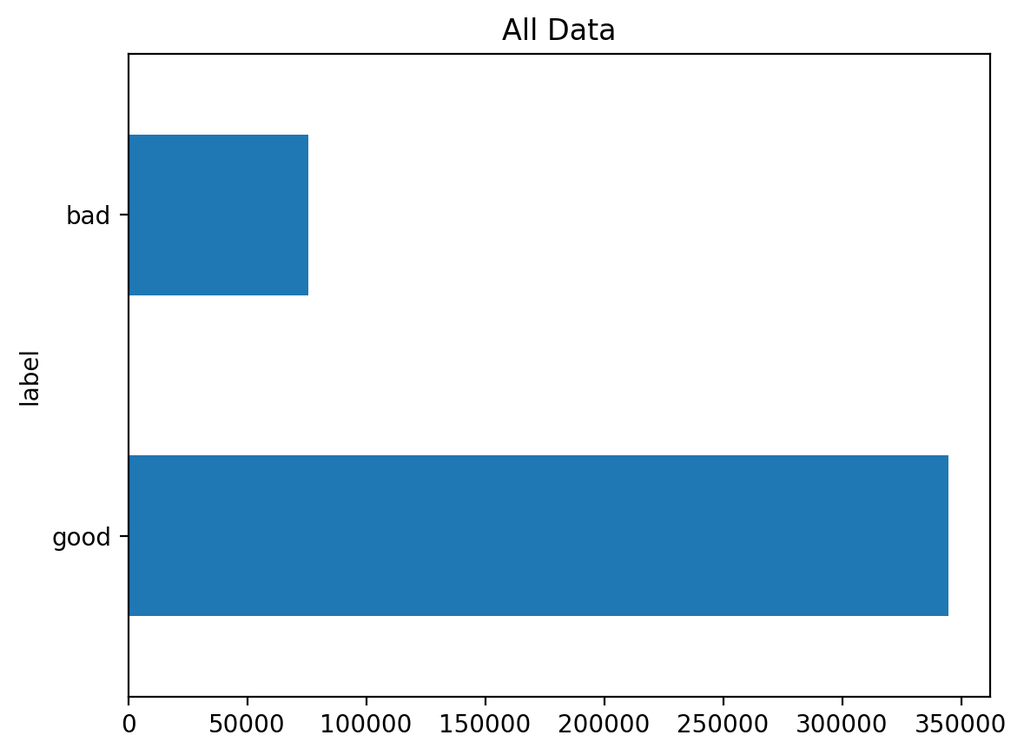

```python
data.label.value_counts().plot.barh()
plt.title('All Data')
plt.show()
```

```python
good, bad = data.label.value_counts()
print(f'Ratio of data between target labels (bad & good) is {bad//bad}:{good//bad}')
```

```
Ratio of data between target labels (bad & good) is 1:4
```

Next, lets find out the most used suffix domain, domain and sub domain. We need to extract subdomains, domains and domain suffixes to be able to do the analysis

```python
# def parsed_url(url):
#     # extract subdomain, domain, and domain suffix from url
#     # if item == '', fill with '<empty>'
#     subdomain, domain, domain_suffix = ('<empty>' if extracted == '' else extracted for extracted in tldextract.extract(url))
#     return [subdomain, domain, domain_suffix]
```

```python
# fix
# i rewrite the previous method
def parsed_url(url):
    extracted = tldextract.extract(url)
    subdomain = extracted.subdomain if extracted.subdomain != '' else '<empty>'
    domain = extracted.domain if extracted.domain != '' else '<empty>'
    domain_suffix = extracted.suffix if extracted.suffix != '' else '<empty>'
    return [subdomain, domain, domain_suffix]
```

```python
def extract_url(data):
    # parsed url
    extract_url_data = [parsed_url(url) for url in data['url']]
    extract_url_data = pd.DataFrame(extract_url_data, columns=['subdomain', 'domain', 'domain_suffix'])
    # concat extracted feature with main data
    data = data.reset_index(drop=True)
    data = pd.concat([data, extract_url_data], axis=1)
    return data
```

```python
train_data = extract_url(train_data)
val_data = extract_url(val_data)
```

```python
def plot(train_data, val_data, column):
    plt.figure(figsize=(10, 17))
    plt.subplot(411)
    plt.title(f'Train data {column}')
    plt.ylabel(column)
    train_data[column].value_counts().head(10).plot.barh()
    plt.subplot(412)
    plt.title(f'Validation data {column}')
    plt.ylabel(column)
    val_data[column].value_counts().head(10).plot.barh()
    plt.subplot(413)
    plt.title(f'Train data {column} (groupped)')
    plt.ylabel(f'(label, {column})')
    train_data.groupby('label')[column].value_counts().head(10).plot.barh()
    plt.subplot(414)
    plt.title(f'Validation data {column} (groupped)')
    plt.ylabel(f'(label, {column})')
    val_data.groupby('label')[column].value_counts().head(10).plot.barh()
    plt.show()
```

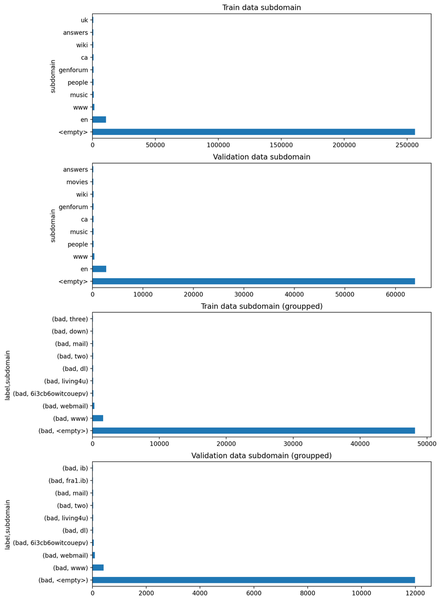

```python
plot(train_data, val_data, 'subdomain')
```

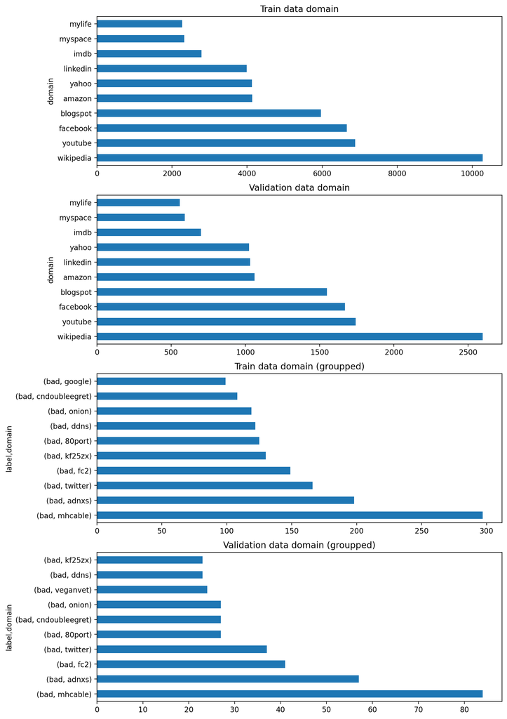

```python
plot(train_data, val_data, 'domain')
```

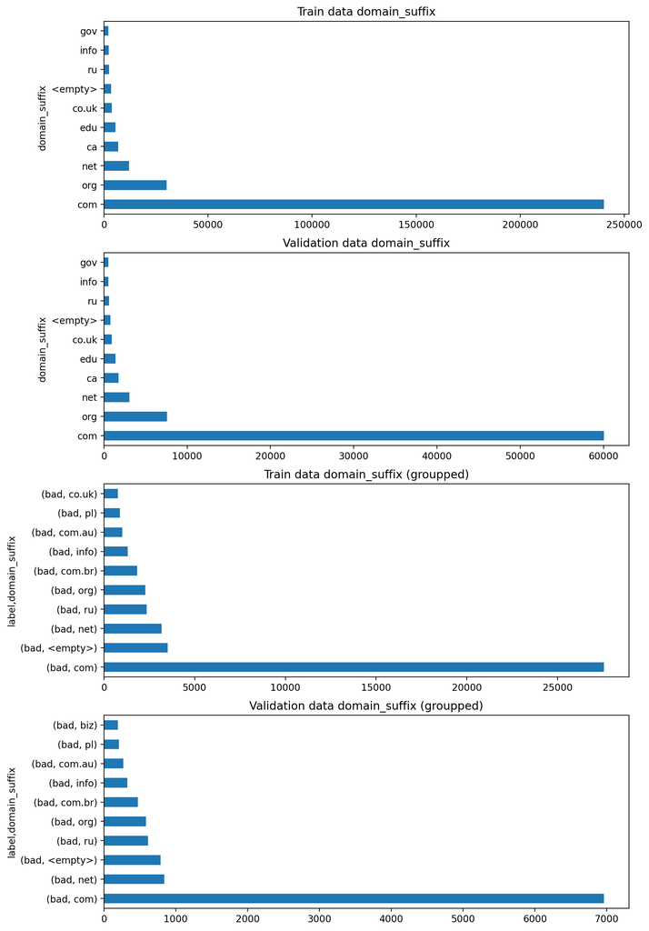

```python
plot(train_data, val_data, 'domain_suffix')
```

Based on the plot above there are interesting things to note, there are websites that have google and twitter domains with bad labels. It's time we do the filter to see data with google domains and Twitter with bad labels

```python
train_data[(train_data['domain'] == 'google') & (train_data['label'] == 'bad')].head()
```

|  | url | label | subdomain | domain | domain_suffix |
| --- | --- | --- | --- | --- | --- |
| 25 | drive.google.com/uc?export=download&amp;id=0B7XzN8DNbJKiQlFNRHdVTmpCd0U | bad | drive | google | com |
| 1571 | accounts.google.com/ServiceLogin?continue=https://drive.google.com/st/auth/host/0Bz9pzRUAjfXaT3RXengxQXV3dlU/ | bad | accounts | google | com |
| 6633 | docs.google.com/document/d/1OKcZKiBvp-c9kOeo9A0ODVkbAxmzpfcZGFW_jf6CbRM/pub | bad | docs | google | com |
| 8390 | docs.google.com/document/d/1-1buo7hGcqSRbCeoJ4OtbQkk0JjzkPEHULycAxHAbd0/pub | bad | docs | google | com |
| 9236 | https://plus.google.com/share?title=FerienWohnung%20in%20centro%20a%20Mantova\|Italien,%20Mantova,%20Mantova\|trans&amp;url=http://b.ems.to/YRR.:boeZ:t7m6q | bad | plus | google | com |

```python
train_data[(train_data['domain'] == 'twitter') & (train_data['label'] == 'bad')].head()
```

|  | url | label | subdomain | domain | domain_suffix |
| --- | --- | --- | --- | --- | --- |
| 697 | twitter.com/CjreLwzL | bad | <empty> | twitter | com |
| 703 | twitter.com/QAwADQA | bad | <empty> | twitter | com |
| 2378 | twitter.com/bvXPoAH | bad | <empty> | twitter | com |
| 2786 | twitter.com/D99oXj1p4sm | bad | <empty> | twitter | com |
| 2886 | twitter.com/wAtADEAMAA | bad | <empty> | twitter | com |

Maybe some of there urls contain malware, who knows :)  
The next step we need to do tokenization on the url so that it can be used as input to the CNN model

```python
tokenizer = Tokenizer(filters='', char_level=True, lower=False, oov_token=1)
# fit only on training data
tokenizer.fit_on_texts(train_data['url'])
n_char = len(tokenizer.word_index.keys())
print(f'N Char: {n_char}')
```

```
N Char: 177
```

```python
train_seq = tokenizer.texts_to_sequences(train_data['url'])
val_seq = tokenizer.texts_to_sequences(val_data['url'])
print('Before tokenization: ')
print(train_data.iloc[0]['url'])
print('\nAfter tokenization: ')
print(train_seq[0])
```

```
Before tokenization:
melangemagazine.com/wp-content/plugins/telekom/vodafone_onlinerechnung

After tokenization:
[12, 2, 14, 4, 11, 20, 2, 12, 4, 20, 4, 43, 5, 11, 2, 13, 8, 3, 12, 6, 26, 17, 15, 8, 3, 11, 7, 2, 11, 7, 6, 17, 14, 19, 20, 5, 11, 9, 6, 7, 2, 14, 2, 28, 3, 12, 6, 30, 3, 16, 4, 25, 3, 11, 2, 29, 3, 11, 14, 5, 11, 2, 10, 2, 8, 18, 11, 19, 11, 20]
```

```python
sequence_length = np.array([len(i) for i in train_seq])
sequence_length = np.percentile(sequence_length, 99).astype(int)
print(f'Sequence length: {sequence_length}')
```

```
Sequence length: 162
```

Each text length has a different length, therefore padding is needed to equalize each text length

```python
train_seq = pad_sequences(train_seq, padding='post', maxlen=sequence_length)
val_seq = pad_sequences(val_seq, padding='post', maxlen=sequence_length)
print('After padding: ')
print(train_seq[0])
```

```
After padding:
[12  2 14  4 11 20  2 12  4 20  4 43  5 11  2 13  8  3 12  6 26 17 15  8
  3 11  7  2 11  7  6 17 14 19 20  5 11  9  6  7  2 14  2 28  3 12  6 30
  3 16  4 25  3 11  2 29  3 11 14  5 11  2 10  2  8 18 11 19 11 20  0  0
  0  0  0  0  0  0  0  0  0  0  0  0  0  0  0  0  0  0  0  0  0  0  0  0
  0  0  0  0  0  0  0  0  0  0  0  0  0  0  0  0  0  0  0  0  0  0  0  0
  0  0  0  0  0  0  0  0  0  0  0  0  0  0  0  0  0  0  0  0  0  0  0  0
  0  0  0  0  0  0  0  0  0  0  0  0  0  0  0  0  0  0]
```

The next step is to normalize so the value has a scale between 0 and 1

```python
train_seq = train_seq / n_char
val_seq = val_seq / n_char
```

save the tokenizer for later use

```python
with open('tokenizer.pkl', 'wb') as f:
    pickle.dump(tokenizer, f)
```

# Encoding Features

We will also encode subdomain, domain, suffix domains and label into numerical variables

```python
def encode_label(label_index, data):
    try:
        return label_index[data]
    except:
        return label_index['<unknown>']
```

```python
unique_value = {}
for feature in ['subdomain', 'domain', 'domain_suffix']:
    # get unique value
    label_index = {label: index for index, label in enumerate(train_data[feature].unique())}
    # add unknown label in last index
    label_index['<unknown>'] = list(label_index.values())[-1] + 1
    # count unique value
    unique_value[feature] = label_index['<unknown>']
    # encode
    train_data.loc[:, feature] = [encode_label(label_index, i) for i in train_data.loc[:, feature]]
    val_data.loc[:, feature] = [encode_label(label_index, i) for i in val_data.loc[:, feature]]
    # save label index
    with open(f'{feature}.pkl', 'wb') as f:
        pickle.dump(label_index, f)
```

```python
for data in [train_data, val_data]:
    data.loc[:, 'label'] = [0 if i == 'good' else 1 for i in data.loc[:, 'label']]
```

```python
print(f"Unique subdomain in Train data: {unique_value['subdomain']}")
print(f"Unique domain in Train data: {unique_value['domain']}")
print(f"Unique domain suffix in Train data: {unique_value['domain_suffix']}")
```

```
Unique subdomain in Train data: 23348
Unique domain in Train data: 98288
Unique domain suffix in Train data: 671
```

# Create CNN Model

```python
def convolution_block(x):
    # 3 sequence conv layer
    conv_3_layer = layers.Conv1D(64, 3, padding='same', activation='elu')(x)
    # 5 sequence conv layer
    conv_5_layer = layers.Conv1D(64, 5, padding='same', activation='elu')(x)
    # concat conv layer
    conv_layer = layers.concatenate([x, conv_3_layer, conv_5_layer])
    # flatten
    conv_layer = layers.Flatten()(conv_layer)
    return conv_layer
```

```python
def embedding_block(unique_value, size):
    input_layer = layers.Input(shape=(1,))
    embedding_layer = layers.Embedding(unique_value, size, input_length=1)(input_layer)
    return input_layer, embedding_layer
```

```python
def create_model(sequence_length, n_char, n_subdomain, n_domain, n_domain_suffix):
    input_layer = []
    # sequence input layer
    sequence_input_layer = layers.Input(shape=(sequence_length,))
    input_layer.append(sequence_input_layer)
    # convolution block
    char_embedding = layers.Embedding(n_char + 1, 32, input_length=sequence_length)(sequence_input_layer)
    conv_layer = convolution_block(char_embedding)
    # entity embedding
    entity_embedding = []
    for n in [n_subdomain, n_domain, n_domain_suffix]:
        size = 4
        input_l, embedding_l = embedding_block(n, size)
        embedding_l = layers.Reshape(target_shape=(size,))(embedding_l)
        input_layer.append(input_l)
        entity_embedding.append(embedding_l)
    # concat all layer
    fc_layer = layers.concatenate([conv_layer, *entity_embedding])
    fc_layer = layers.Dropout(rate=0.5)(fc_layer)
    # dense layer
    fc_layer = layers.Dense(128, activation='elu')(fc_layer)
    fc_layer = layers.Dropout(rate=0.2)(fc_layer)
    # output layer
    output_layer = layers.Dense(1, activation='sigmoid')(fc_layer)
    model = models.Model(inputs=input_layer, outputs=output_layer)
    model.compile(optimizer='adam', loss='binary_crossentropy', metrics=[metrics.Precision(), metrics.Recall()])
    return model
```

```python
# reset session
backend.clear_session()
os.environ['PYTHONHASHSEED'] = '0'
np.random.seed(0)
random.seed(0)
# tf.set_random_seed(0)
tf.random.set_seed(0)

# create model
model = create_model(sequence_length, n_char, unique_value['subdomain'], unique_value['domain'], unique_value['domain_suffix'])
model.summary()
```

```
Model: "functional"
```

```
┏━━━━━━━━━━━━━━━━━━━━━┳━━━━━━━━━━━━━━━━━━━┳━━━━━━━━━━━━┳━━━━━━━━━━━━━━━━━━━┓
┃ Layer (type)        ┃ Output Shape      ┃    Param # ┃ Connected to      ┃
┡━━━━━━━━━━━━━━━━━━━━━╇━━━━━━━━━━━━━━━━━━━╇━━━━━━━━━━━━╇━━━━━━━━━━━━━━━━━━━┩
│ input_layer         │ (None, 162)       │          0 │ -                 │
│ (InputLayer)        │                   │            │                   │
├─────────────────────┼───────────────────┼────────────┼───────────────────┤
│ embedding           │ (None, 162, 32)   │      5,696 │ input_layer[0][0] │
│ (Embedding)         │                   │            │                   │
├─────────────────────┼───────────────────┼────────────┼───────────────────┤
│ conv1d (Conv1D)     │ (None, 162, 64)   │      6,208 │ embedding[0][0]   │
├─────────────────────┼───────────────────┼────────────┼───────────────────┤
│ conv1d_1 (Conv1D)   │ (None, 162, 64)   │     10,304 │ embedding[0][0]   │
├─────────────────────┼───────────────────┼────────────┼───────────────────┤
│ input_layer_1       │ (None, 1)         │          0 │ -                 │
│ (InputLayer)        │                   │            │                   │
├─────────────────────┼───────────────────┼────────────┼───────────────────┤
│ input_layer_2       │ (None, 1)         │          0 │ -                 │
│ (InputLayer)        │                   │            │                   │
├─────────────────────┼───────────────────┼────────────┼───────────────────┤
│ input_layer_3       │ (None, 1)         │          0 │ -                 │
│ (InputLayer)        │                   │            │                   │
├─────────────────────┼───────────────────┼────────────┼───────────────────┤
│ concatenate         │ (None, 162, 160)  │          0 │ embedding[0][0],  │
│ (Concatenate)       │                   │            │ conv1d[0][0],     │
│                     │                   │            │ conv1d_1[0][0]    │
├─────────────────────┼───────────────────┼────────────┼───────────────────┤
│ embedding_1         │ (None, 1, 4)      │     93,392 │ input_layer_1[0]… │
│ (Embedding)         │                   │            │                   │
├─────────────────────┼───────────────────┼────────────┼───────────────────┤
│ embedding_2         │ (None, 1, 4)      │    393,152 │ input_layer_2[0]… │
│ (Embedding)         │                   │            │                   │
├─────────────────────┼───────────────────┼────────────┼───────────────────┤
│ embedding_3         │ (None, 1, 4)      │      2,684 │ input_layer_3[0]… │
│ (Embedding)         │                   │            │                   │
├─────────────────────┼───────────────────┼────────────┼───────────────────┤
│ flatten (Flatten)   │ (None, 25920)     │          0 │ concatenate[0][0] │
├─────────────────────┼───────────────────┼────────────┼───────────────────┤
│ reshape (Reshape)   │ (None, 4)         │          0 │ embedding_1[0][0] │
├─────────────────────┼───────────────────┼────────────┼───────────────────┤
│ reshape_1 (Reshape) │ (None, 4)         │          0 │ embedding_2[0][0] │
├─────────────────────┼───────────────────┼────────────┼───────────────────┤
│ reshape_2 (Reshape) │ (None, 4)         │          0 │ embedding_3[0][0] │
├─────────────────────┼───────────────────┼────────────┼───────────────────┤
│ concatenate_1       │ (None, 25932)     │          0 │ flatten[0][0],    │
│ (Concatenate)       │                   │            │ reshape[0][0],    │
│                     │                   │            │ reshape_1[0][0],  │
│                     │                   │            │ reshape_2[0][0]   │
├─────────────────────┼───────────────────┼────────────┼───────────────────┤
│ dropout (Dropout)   │ (None, 25932)     │          0 │ concatenate_1[0]… │
├─────────────────────┼───────────────────┼────────────┼───────────────────┤
│ dense (Dense)       │ (None, 128)       │  3,319,424 │ dropout[0][0]     │
├─────────────────────┼───────────────────┼────────────┼───────────────────┤
│ dropout_1 (Dropout) │ (None, 128)       │          0 │ dense[0][0]       │
├─────────────────────┼───────────────────┼────────────┼───────────────────┤
│ dense_1 (Dense)     │ (None, 1)         │        129 │ dropout_1[0][0]   │
└─────────────────────┴───────────────────┴────────────┴───────────────────┘
```

```
 Total params: 3,830,989 (14.61 MB)
```

```
 Trainable params: 3,830,989 (14.61 MB)
```

```
 Non-trainable params: 0 (0.00 B)
```

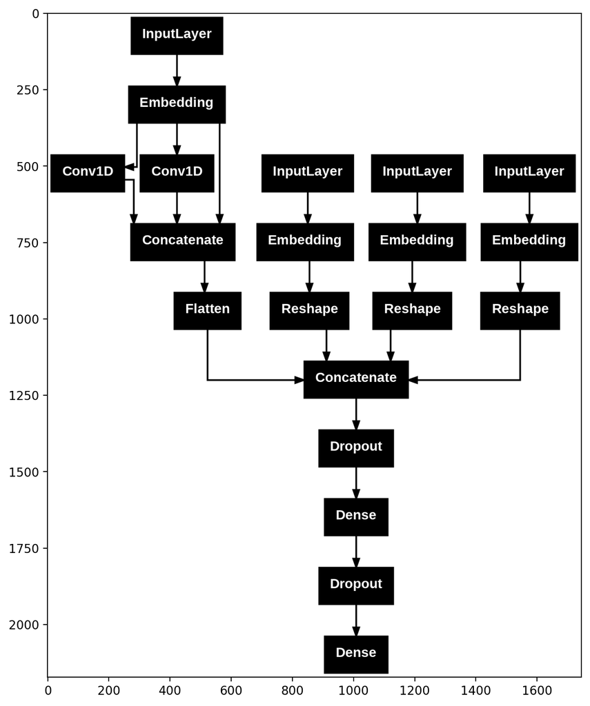

```python
plot_model(model, to_file='model.png')
model_image = mpimg.imread('model.png')
# plt.figure(figsize=(75, 75))
plt.figure(figsize=(10,10))
plt.imshow(model_image)
plt.show()
```

The above has 4 encoded inputs:

1. the first input came from URL that has been done tokenization and padding.
2. subdomains,
3. domains, and
4. suffix domains

URL input will pass through embedding layer and convolution layer while other input will pass embedding layer. Then the results from each input will be concatenated.

# Model Training

```python
train_x = [train_seq, train_data['subdomain'], train_data['domain'], train_data['domain_suffix']]
train_y = train_data['label']
val_x = [val_seq, val_data['subdomain'], val_data['domain'], val_data['domain_suffix']]
val_y = val_data['label']
```

```python
# i added below code
train_x = [
    np.array(train_seq, dtype='float32'),
    np.array(train_data['subdomain'], dtype='int32'),
    np.array(train_data['domain'], dtype='int32'),
    np.array(train_data['domain_suffix'], dtype='int32')
]

val_x = [
    np.array(val_seq, dtype='float32'),
    np.array(val_data['subdomain'], dtype='int32'),
    np.array(val_data['domain'], dtype='int32'),
    np.array(val_data['domain_suffix'], dtype='int32')
]

train_y = np.array(train_data['label'], dtype='int32')
val_y = np.array(val_data['label'], dtype='int32')
```

```python
early_stopping = [EarlyStopping(monitor='val_precision', patience=5, restore_best_weights=True, mode='max')]
# history = model.fit(train_x, train_y, batch_size=64, epochs=25, verbose=1, validation_data=[val_x, val_y], shuffle=True, callbacks=early_stopping)

# history = model.fit(train_x, train_y, batch_size=64, epochs=25, verbose=1,
#                     validation_data=(val_x, val_y), shuffle=True, callbacks=early_stopping)
history = model.fit(train_x, train_y, batch_size=64, epochs=25, verbose=1,
                    validation_data=(val_x, val_y), shuffle=True, callbacks=early_stopping)

# the original epoch was 25
model.save('model.h5')


# the time of training on t4 gpu in google colab for 25 epoch : around 10 minutes
```

```
5256/5256 ━━━━━━━━━━━━━━━━━━━━ 44s 7ms/step - loss: 0.3644 - precision: 0.7186 - recall: 0.3100 - val_loss: 0.1464 - val_precision: 0.9577 - val_recall: 0.7440
5256/5256 ━━━━━━━━━━━━━━━━━━━━ 73s 6ms/step - loss: 0.1419 - precision: 0.9130 - recall: 0.7670 - val_loss: 0.1171 - val_precision: 0.9810 - val_recall: 0.7894
5256/5256 ━━━━━━━━━━━━━━━━━━━━ 32s 6ms/step - loss: 0.0844 - precision: 0.9513 - recall: 0.8718 - val_loss: 0.1930 - val_precision: 0.9930 - val_recall: 0.7519
5256/5256 ━━━━━━━━━━━━━━━━━━━━ 41s 6ms/step - loss: 0.0559 - precision: 0.9711 - recall: 0.9174 - val_loss: 0.1980 - val_precision: 0.9928 - val_recall: 0.7634
5256/5256 ━━━━━━━━━━━━━━━━━━━━ 32s 6ms/step - loss: 0.0434 - precision: 0.9817 - recall: 0.9359 - val_loss: 0.2409 - val_precision: 0.9927 - val_recall: 0.7336
5256/5256 ━━━━━━━━━━━━━━━━━━━━ 30s 6ms/step - loss: 0.0387 - precision: 0.9849 - recall: 0.9433 - val_loss: 0.2820 - val_precision: 0.9840 - val_recall: 0.7281
5256/5256 ━━━━━━━━━━━━━━━━━━━━ 43s 6ms/step - loss: 0.0332 - precision: 0.9883 - recall: 0.9507 - val_loss: 0.3170 - val_precision: 0.9949 - val_recall: 0.7254
5256/5256 ━━━━━━━━━━━━━━━━━━━━ 41s 6ms/step - loss: 0.0321 - precision: 0.9892 - recall: 0.9518 - val_loss: 0.3253 - val_precision: 0.9946 - val_recall: 0.7243
5256/5256 ━━━━━━━━━━━━━━━━━━━━ 32s 6ms/step - loss: 0.0306 - precision: 0.9903 - recall: 0.9541 - val_loss: 0.2945 - val_precision: 0.9844 - val_recall: 0.7275
5256/5256 ━━━━━━━━━━━━━━━━━━━━ 40s 6ms/step - loss: 0.0297 - precision: 0.9909 - recall: 0.9550 - val_loss: 0.3229 - val_precision: 0.9943 - val_recall: 0.7251
5256/5256 ━━━━━━━━━━━━━━━━━━━━ 41s 6ms/step - loss: 0.0290 - precision: 0.9907 - recall: 0.9559 - val_loss: 0.2904 - val_precision: 0.9844 - val_recall: 0.7269
5256/5256 ━━━━━━━━━━━━━━━━━━━━ 32s 6ms/step - loss: 0.0285 - precision: 0.9915 - recall: 0.9574 - val_loss: 0.2993 - val_precision: 0.9940 - val_recall: 0.7261
```

```
WARNING:absl:You are saving your model as an HDF5 file via `model.save()` or `keras.saving.save_model(model)`. This file format is considered legacy. We recommend using instead the native Keras format, e.g. `model.save('my_model.keras')` or `keras.saving.save_model(model, 'my_model.keras')`.
```

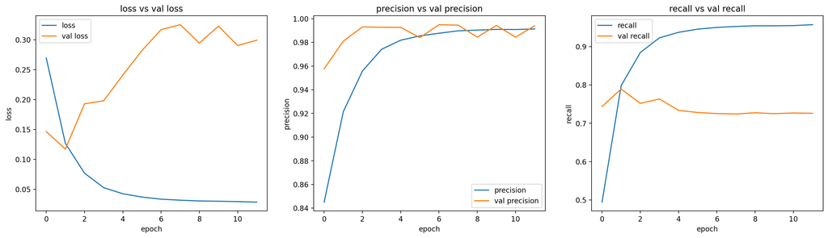

```python
plt.figure(figsize=(20, 5))
for index, key in enumerate(['loss', 'precision', 'recall']):
    plt.subplot(1, 3, index+1)
    plt.plot(history.history[key], label=key)
    plt.plot(history.history[f'val_{key}'], label=f'val {key}')
    plt.legend()
    plt.title(f'{key} vs val {key}')
    plt.ylabel(f'{key}')
    plt.xlabel('epoch')
```

# Model Validation

```python
val_pred = model.predict(val_x)
val_pred = np.where(val_pred[:, 0] >= 0.5, 1, 0)
print(f'Validation Data:\n{val_data.label.value_counts()}')
print(f'\n\nConfusion Matrix:\n{confusion_matrix(val_y, val_pred)}')
print(f'\n\nClassification Report:\n{classification_report(val_y, val_pred)}')
```

```
2628/2628 ━━━━━━━━━━━━━━━━━━━━ 7s 2ms/step
Validation Data:
label
0    68964
1    15129
Name: count, dtype: int64


Confusion Matrix:
[[68908    56]
 [ 4154 10975]]


Classification Report:
              precision    recall  f1-score   support

           0       0.94      1.00      0.97     68964
           1       0.99      0.73      0.84     15129

    accuracy                           0.95     84093
   macro avg       0.97      0.86      0.90     84093
weighted avg       0.95      0.95      0.95     84093
```